# Punto 2° Parcial: Ajuste de un modelo de R.L.M

Universidad Nacional de Colombia Analisís de Regresión 2022-1S Medellín, Colombia 2022

Daniel Villa 1005087556

Juan Pablo Vanegas 1000640165

[figure not shown]

# Objetivos:

Crear un modelo ajustado de R.L.M. por el cual se pueda predecir la estatura de un individuo (discrimiando por genero) sabiendo las estaturas de los padres (madre y padre) utilizando el software estadístico *R*.

## Objetivos específicos

- Plantear el modelo de R.L.M.
- Interpretar los parámetros del modelo.
- Determinar si el efecto de las estaturas de los padres sobre la estatura del sujeto es significativo.
- Interpretar nuestro $R^2$.
- Validar los supuestos del modelo.
- Aplicar la prueba de falta de ajuste.

# Antecedentes Relevantes

La población encuestada, pertenece a estudiantes de la Universidad Nacional de Colombia sede Medellín de diferentes carreras, es decir, la mayoria de los sujetos de la muestra son jovenes entre los 18 y los 25 años, además decidimos que solamente aquellos que tenian la posibilidad de saber las estaturas de sus padres entraban a nuestra base de datos, ya que el porceso sería más arduo si tomamos datos donde nos faltan llenar valores en las celdas correspondientes.

# Variables de respuesta:

En nuestro caso será la estatura del sujeto (Hombre o Mujer) para ajustar un modelo para predecir por medio de nuestras variables predictoras la esturura del sujeto.

# Variable de Control:

En este caso tendremos 3 varibles haciendo de este un modelo de R.L.M.

1. Estatura del Padre.
2. Estatura del Madre.
3. Genero del sujeto.

# Creación del Modelo

Nuestro modelo tendra la forma de:

$Y_i = \beta_0 + \beta_1X_{i1} + \beta_2X_{i2} + \beta_3X_{i3}+\varepsilon_i, \ i=1,...,30 \ \ donde \ \varepsilon_i \sim N(0,\sigma^2)$

Para llegar a lo anterior primero miraremos nuestra base de datos y como se comportan estas variables *(algunos datos…)*.

| est_sujeto | genero | exp_sujeto | est_madre | est_padre | ced_sujeto | ced_madre | ced_padre | exp_padre | exp_madre |
| --- | --- | --- | --- | --- | --- | --- | --- | --- | --- |
| 180 | F | 1/11/2017 | 151 | 163 | 2567 | 1262 | 8323 | 18/10/1965 | 1/11/1988 |
| 181 | M | 22/6/2016 | 158 | 175 | 6044 | 5350 | 0316 | 21/6/1984 | 15/12/1974 |
| 187 | M | 26/9/2020 | 159 | 170 | 6946 | 4240 | 0659 | 31/12/1977 | 6/4/1992 |
| 155 | M | 8/10/2020 | 162 | 183 | 7023 | 2121 | 4144 | 21/1/1970 | 4/3/2000 |
| 159 | F | 21/6/2016 | 169 | 175 | 1791 | 7832 | 3727 | 11/6/1987 | 19/2/2000 |
| . | . | . | . | . | . | . | . | . | . |
| . | . | . | . | . | . | . | . | . | . |
| . | . | . | . | . | . | . | . | . | . |
| 150 | M | 17/11/2016 | 167 | 184 | 8126 | 9626 | 9357 | 30/6/1981 | 13/5/1998 |
| 154 | F | 5/2/2020 | 169 | 173 | 9538 | 2408 | 4497 | 12/9/1982 | 30/3/1990 |
| 167 | F | 7/9/2021 | 150 | 181 | 2894 | 7612 | 4657 | 22/3/1980 | 31/1/1984 |
| 156 | M | 18/6/2020 | 163 | 164 | 8849 | 4763 | 8827 | 9/6/1989 | 23/1/1998 |
| 170 | F | 4/8/2017 | 154 | 186 | 9227 | 4016 | 1264 | 29/7/1968 | 10/1/1973 |

Definimos nuestras variables:

- `est_sujeto`: Estatura en cm del sujeto encuestado.
- `genero`: Genero del sujeto encuestado.
- `exp_sujeto`: Fecha de expedición de la cedula del sujeto.
- `est_madre`: Estatura de la madre del sujeto en cm.
- `est_padre`: Estatura del padre del sujeto en cm.
- `ced_sujeto`: Ultimos cuatro dijitos de la cedula del sujeto encuestado.
- `ced_madre`: Ultimos cuatro dijitos de la cedula de la madre.
- `ced_padre`: Ultimos cuatro dijitos de la cedula del padre.
- `exp_madre`: Fecha de expedición de la cedula de la madre.
- `exp_padre`: Fecha de expedición de la cedula del padre.

# Análisis de correlación

Comenzamos representando los datos en una nube de puntos múltiple, donde vemos la relación entre cada par de variables.

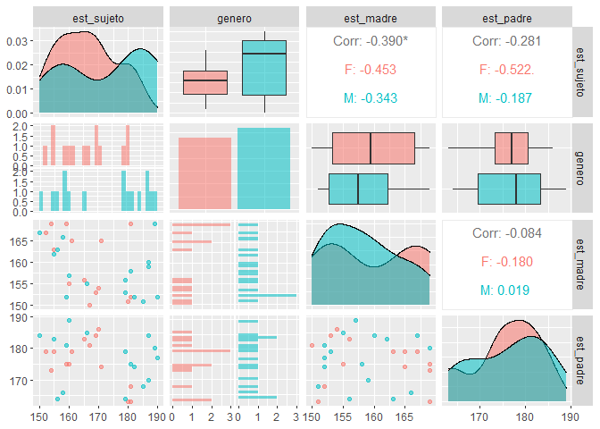

Según la sigueinte tabla veremos que tan debil o fuerte son los datos respecto a otros:

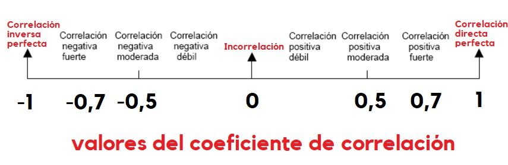

como podemos apreciar nuestras 3 correlaciones entre cada variable predictora y nuestra $Y$ es una *Correlación Negativa débil* ya que ninguno supera $\pm 0.5$.

# Ajuste del modelo

```
##
## Call:
## lm(formula = est ~ est_pa + est_ma + genero, data = stature)
##
## Residuals:
##     Min      1Q  Median      3Q     Max
## -19.854  -6.954   0.101   4.956  26.325
##
## Coefficients:
##             Estimate Std. Error t value Pr(>|t|)
## (Intercept) 381.5306    73.4427   5.195 2.01e-05 ***
## est_pa       -0.5417     0.2766  -1.959   0.0609 .
## est_ma       -0.7519     0.3204  -2.346   0.0269 *
## generoM       5.7221     4.1315   1.385   0.1778
## ---
## Signif. codes:  0 '***' 0.001 '**' 0.01 '*' 0.05 '.' 0.1 ' ' 1
##
## Residual standard error: 11.2 on 26 degrees of freedom
## Multiple R-squared:  0.3025, Adjusted R-squared:  0.222
## F-statistic: 3.758 on 3 and 26 DF,  p-value: 0.02294
```

El error típico residual es `11.2`, la $R^2=0.3025$, aunque para el modelo múltiple es mejor fijarnos en su valor ajustado $R_a^2=0.222$. Esto que significa que la recta de regresión explica el 22.22% de la variabilidad del modelo. Además, `F = 3.758` con una significación $p<0.05$, lo que nos dice que nuestro modelo de regresión resulta un poco mejor que el modelo básico.

# Comparación de modelos

Pretendemos seleccionar el “mejor” subconjunto de predictores por varias razones:

1. Explicar los datos de la manera más simple. Debemos eliminar predictores redundantes.
2. Predictores innecesarios añade ruido a las estimaciones.
3. La causa de la multicolinealidad es tener demasiadas variables tratando de hacer el mismo trabajo. Eliminar el exceso de predictores ayuda a la interpretación del modelo.
4. Si vamos a utilizar el modelo para la predicción, podemos ahorrar tiempo y/o dinero al no medir predictores redundantes.

$modelo \ 1: \ est \sim est_{ma}+est_{pa}+genero$

$modelo \ 2: \ est \sim est_{ma}+genero$

$modelo \ 3: \ est \sim est_{pa}+genero$

$modelo \ 4: \ est \sim est_{ma}$

$modelo \ 5: \ est \sim est_{pa}$

$modelo \ 6: \ est \sim genero$

Vamos a ajustar cada uno de los modelos

```
##
## Call:
## lm(formula = est ~ est_ma + genero, data = stature)
##
## Residuals:
##     Min      1Q  Median      3Q     Max
## -18.075  -9.035  -1.057   8.030  23.859
##
## Coefficients:
##             Estimate Std. Error t value Pr(>|t|)
## (Intercept) 278.2976    53.7713   5.176  1.9e-05 ***
## est_ma       -0.7020     0.3358  -2.091   0.0461 *
## generoM       5.4878     4.3413   1.264   0.2170
## ---
## Signif. codes:  0 '***' 0.001 '**' 0.01 '*' 0.05 '.' 0.1 ' ' 1
##
## Residual standard error: 11.77 on 27 degrees of freedom
## Multiple R-squared:  0.1995, Adjusted R-squared:  0.1402
## F-statistic: 3.365 on 2 and 27 DF,  p-value: 0.04957
```

```
##
## Call:
## lm(formula = est ~ est_pa + genero, data = stature)
##
## Residuals:
##     Min      1Q  Median      3Q     Max
## -22.784  -9.021   2.940   8.162  18.059
##
## Coefficients:
##             Estimate Std. Error t value Pr(>|t|)
## (Intercept) 252.2777    52.4691   4.808  5.1e-05 ***
## est_pa       -0.4902     0.2978  -1.646    0.111
## generoM       6.9006     4.4298   1.558    0.131
## ---
## Signif. codes:  0 '***' 0.001 '**' 0.01 '*' 0.05 '.' 0.1 ' ' 1
##
## Residual standard error: 12.1 on 27 degrees of freedom
## Multiple R-squared:  0.1548, Adjusted R-squared:  0.09216
## F-statistic: 2.472 on 2 and 27 DF,  p-value: 0.1033
```

```
##
## Call:
## lm(formula = est ~ est_ma, data = stature)
##
## Residuals:
##     Min      1Q  Median      3Q     Max
## -15.884 -10.284  -3.723   7.131  26.948
##
## Coefficients:
##             Estimate Std. Error t value Pr(>|t|)
## (Intercept) 289.6144    53.5839   5.405 9.18e-06 ***
## est_ma       -0.7548     0.3367  -2.242   0.0331 *
## ---
## Signif. codes:  0 '***' 0.001 '**' 0.01 '*' 0.05 '.' 0.1 ' ' 1
##
## Residual standard error: 11.9 on 28 degrees of freedom
## Multiple R-squared:  0.1522, Adjusted R-squared:  0.1219
## F-statistic: 5.025 on 1 and 28 DF,  p-value: 0.0331
```

```
##
## Call:
## lm(formula = est ~ est_pa, data = stature)
##
## Residuals:
##      Min       1Q   Median       3Q      Max
## -19.3440 -10.9008   0.4737   9.9393  21.2097
##
## Coefficients:
##             Estimate Std. Error t value Pr(>|t|)
## (Intercept) 252.7696    53.7882   4.699 6.31e-05 ***
## est_pa       -0.4721     0.3051  -1.548    0.133
## ---
## Signif. codes:  0 '***' 0.001 '**' 0.01 '*' 0.05 '.' 0.1 ' ' 1
##
## Residual standard error: 12.4 on 28 degrees of freedom
## Multiple R-squared:  0.0788, Adjusted R-squared:  0.0459
## F-statistic: 2.395 on 1 and 28 DF,  p-value: 0.1329
```

```
##
## Call:
## lm(formula = est ~ genero, data = stature)
##
## Residuals:
##     Min      1Q  Median      3Q     Max
## -22.688 -11.821   1.929  11.562  17.312
##
## Coefficients:
##             Estimate Std. Error t value Pr(>|t|)
## (Intercept)  166.071      3.330  49.874   <2e-16 ***
## generoM        6.616      4.560   1.451    0.158
## ---
## Signif. codes:  0 '***' 0.001 '**' 0.01 '*' 0.05 '.' 0.1 ' ' 1
##
## Residual standard error: 12.46 on 28 degrees of freedom
## Multiple R-squared:  0.06994,    Adjusted R-squared:  0.03672
## F-statistic: 2.106 on 1 and 28 DF,  p-value: 0.1579
```

Para evitar la elección subjetiva del mejor modelo, podemos comparar todos los modelos mediante una tabla ANOVA conjunta para cada par de modelos.

> Nota: Se escoje el de menor error estandar (RSS)

| Res.Df | RSS | Df | Sum of Sq | F | Pr(>F) |
| --- | --- | --- | --- | --- | --- |
| 27 | 3740.781 | NA | NA | NA | NA |
| 27 | 3949.951 | 0 | -209.1702 | NA | NA |

| Res.Df | RSS | Df | Sum of Sq | F | Pr(>F) |
| --- | --- | --- | --- | --- | --- |
| 27 | 3740.781 | NA | NA | NA | NA |
| 28 | 3962.171 | -1 | -221.3902 | 1.597938 | 0.2170003 |

| Res.Df | RSS | Df | Sum of Sq | F | Pr(>F) |
| --- | --- | --- | --- | --- | --- |
| 27 | 3740.781 | NA | NA | NA | NA |
| 28 | 4304.956 | -1 | -564.1753 | 4.072073 | 0.0536355 |

| Res.Df | RSS | Df | Sum of Sq | F | Pr(>F) |
| --- | --- | --- | --- | --- | --- |
| 27 | 3740.781 | NA | NA | NA | NA |
| 28 | 4346.366 | -1 | -605.5851 | 4.370958 | 0.0461022 |

```
## [1] "Mejor modelo del 2 al 6 con menor RSS"
```

| Res.Df | RSS | Df | Sum of Sq | F | Pr(>F) |
| --- | --- | --- | --- | --- | --- |
| 27 | 3740.781 | NA | NA | NA | NA |
| 26 | 3259.715 | 1 | 481.066 | 3.837058 | 0.0609385 |

# Selección del “mejor” modelo

Existen distintos métodos a la hora de construir un modelo complejo de regresión con varios predictores

- El **método jerárquico** en el que se seleccionan los predictores basándose en un trabajo anterior y el investigador decide en qué orden introducir las variables predictoras al modelo.
- El **método de entrada forzada** en el que todas las variables entran a la fuerza en el modelo simultáneamente.
- Los **métodos paso a paso** que se basan en un criterio matemático para decidir el orden en que los predictores entran en el modelo.

Nosotros vamos a utilizar en R los métodos paso a paso

## Resumen de las variables de interes

```
##       est        genero     est_ma          est_pa
##  Min.   :150.0   F:14   Min.   :150.0   Min.   :163.0
##  1st Qu.:159.0   M:16   1st Qu.:153.0   1st Qu.:170.8
##  Median :168.0          Median :157.5   Median :178.0
##  Mean   :169.6          Mean   :159.0   Mean   :176.2
##  3rd Qu.:181.0          3rd Qu.:165.0   3rd Qu.:182.5
##  Max.   :190.0          Max.   :169.0   Max.   :189.0
```

En todas las variables explicativas los valores de la media y la mediana son muy cercanos, lo cual es muy bueno.

## Correlación

```
##
##  Pearson's product-moment correlation
##
## data:  df$est and df$est_ma
## t = -2.2416, df = 28, p-value = 0.0331
## alternative hypothesis: true correlation is not equal to 0
## 95 percent confidence interval:
##  -0.65788264 -0.03466696
## sample estimates:
##        cor
## -0.3900645
```

```
##
##  Pearson's product-moment correlation
##
## data:  df$est and df$est_pa
## t = -1.5476, df = 28, p-value = 0.1329
## alternative hypothesis: true correlation is not equal to 0
## 95 percent confidence interval:
##  -0.58211099  0.08850857
## sample estimates:
##        cor
## -0.2807117
```

```
##
##  Pearson's product-moment correlation
##
## data:  df$est_pa and df$est_ma
## t = -0.44376, df = 28, p-value = 0.6606
## alternative hypothesis: true correlation is not equal to 0
## 95 percent confidence interval:
##  -0.4308663  0.2852892
## sample estimates:
##         cor
## -0.08356935
```

Como podemos ver nuestras variables estan correlacionada negativamente, además tenemos que no superan el umbral de $\pm 0.5$ lo que conlleva a que tenga una correlación debil.

Si miramos sus $p-value$ podemos encontrar que solamente para el caso de las madres se rechaza ña hipotesís $H_0$ donde se asume que la correlación entre este tipo de variables pude ser igual a cero, es decir, que de alguna forma los datos estan correlacionados negativamente entre la estatura del sujeto y de la madre.

[figure not shown]

> Volvemos a refrescar un poco la memoria con el **modelo2**:

```
##                Estimate Std. Error   t value     Pr(>|t|)
## (Intercept) 278.2976107 53.7712777  5.175581 1.900584e-05
## est_ma       -0.7020405  0.3357947 -2.090684 4.610222e-02
## generoM       5.4877921  4.3412792  1.264096 2.170003e-01
```

se nota puede notar viendo el valor $Pr(|t|)$ que la variable genero es la unica que se rechaza, dentro de la hipotesís que el $\beta_i =0$, es decir, nuestr modelo solamente se complementaria de los datos de la estatura de la madre.

# Elección de los predictores

En este caso, al solo haber dos predictores, a partir del summary del modelo se identifica que solo la variable `est_ma` es importante.

```
##
## Call:
## lm(formula = est ~ est_ma + genero, data = stature)
##
## Residuals:
##     Min      1Q  Median      3Q     Max
## -18.075  -9.035  -1.057   8.030  23.859
##
## Coefficients:
##             Estimate Std. Error t value Pr(>|t|)
## (Intercept) 278.2976    53.7713   5.176  1.9e-05 ***
## est_ma       -0.7020     0.3358  -2.091   0.0461 *
## generoM       5.4878     4.3413   1.264   0.2170
## ---
## Signif. codes:  0 '***' 0.001 '**' 0.01 '*' 0.05 '.' 0.1 ' ' 1
##
## Residual standard error: 11.77 on 27 degrees of freedom
## Multiple R-squared:  0.1995, Adjusted R-squared:  0.1402
## F-statistic: 3.365 on 2 and 27 DF,  p-value: 0.04957
```

# Condiciones para la regresión múltiple lineal

## Relación lineal entre los predictores numéricos y la variable dependiente:

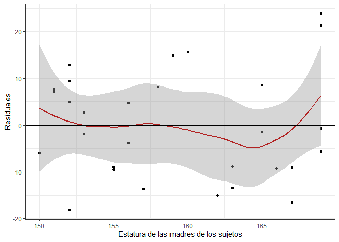

Se satisface la condición de linealidad. Se aprecian posibles datos atípicos.

## Distribución normal de los residuos:

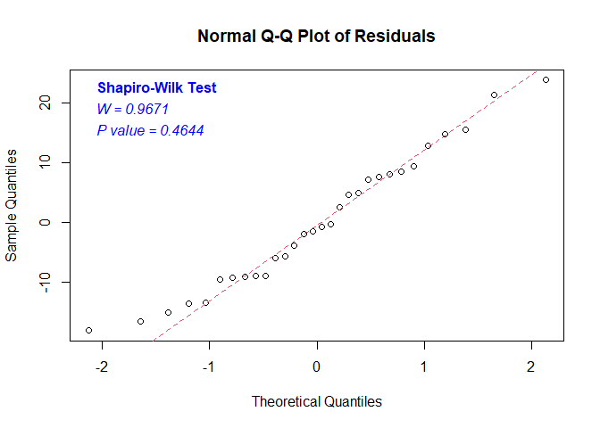

apesar de los datos atipicos se observa que cumple con la normalidad de los residuos.

Nos surge una duda, *¿estos datos atípicos estarán influenciando nuestros datos de alguna manera?*

## Variabilidad constante de los residuos:

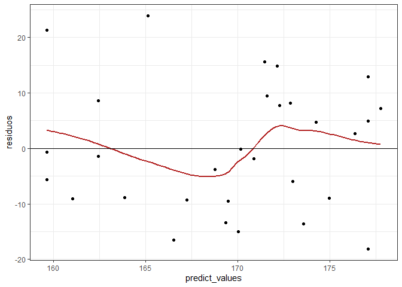

```r
ggplot(data = data.frame(predict_values = predict(modelo2),
                                residuos = residuals(modelo2)),
              aes(x = predict_values, y = residuos))+
         geom_point()+
         geom_smooth(color = "firebrick", se = FALSE)+
         geom_hline(yintercept = 0)+
         theme_bw()
```

```r
bptest(modelo2)
```

```
##
##  studentized Breusch-Pagan test
##
## data:  modelo2
## BP = 8.9341, df = 2, p-value = 0.01148
```

Como podemos ver nuestros $\varepsilon_i$ no tienen un varianza constante, apra ello miraremos estos datos atípicos y si hay necesidad de transformar los datos o aplicar un modelo donde las varianzas no sean constantes.

> Nota: No multicolinialidad: Dado que solo hay un predictor cuantitativo no se puede dar colinialidad.

## Autocorrelación:

```r
dwt(modelo2,alternative = "two.sided")
```

```
##  lag Autocorrelation D-W Statistic p-value
##    1     -0.03978963      2.063677   0.836
##  Alternative hypothesis: rho != 0
```

No hay evidencia de autocorrelación

## Identificación de posibles valores atípicos o influyentes

```r
outlierTest(modelo2)
```

```
## No Studentized residuals with Bonferroni p < 0.05
## Largest |rstudent|:
##   rstudent unadjusted p-value Bonferroni p
## 9 2.392447           0.024254      0.72762
```

```r
summary(influence.measures(modelo2))
```

```
## Potentially influential observations of
##   lm(formula = est ~ est_ma + genero, data = stature) :
##
##   dfb.1_ dfb.est_ dfb.gnrM dffit   cov.r cook.d hat
## 9 -0.80   0.80     0.54     1.03_*  0.73  0.30   0.16
```

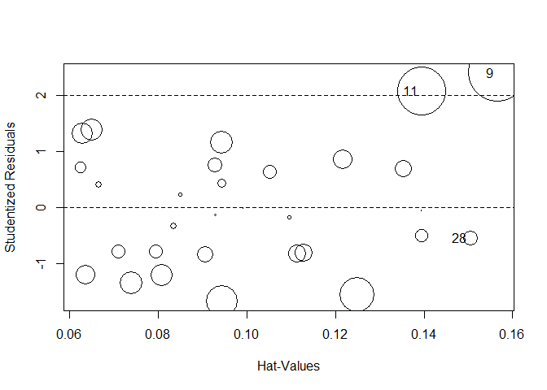

|  | StudRes | Hat | CookD |
| --- | --- | --- | --- |
| 9 | 2.3924473 | 0.1565516 | 0.3013984 |
| 11 | 2.0706534 | 0.1394605 | 0.2064776 |
| 28 | -0.5450432 | 0.1505058 | 0.0180131 |

```r
influencePlot(modelo2)
```

# Apendice:

## listas de Figuras:

1. Correlation plot.
2. Residuales vs Est_Madre.
3. QQnorm norm Residuales.
4. Predict vs Residuos
5. Infuence plot.

## Codigo:

```
## ----message=FALSE, warning=FALSE, include=FALSE--------------------------
library(readr)
library(tidyverse)
library(kableExtra)
library(magrittr)
library(ggExtra)
library(GGally)
library(janitor)
library(tidystats)
library(car)
library(faraway)
library(lmtest)
library(graphics)
# lectura de la base de datos:
stature <- read_csv("estaturas.csv")


## ----echo=FALSE, message=FALSE, warning=FALSE-----------------------------
kable(rbind(head(stature, n = 5),rep(".", ncol(stature)),
            rep(".", ncol(stature)),rep(".", ncol(stature)),
            tail(stature, n = 5)),digits = 30, align = "c")


## ----echo=FALSE, message=FALSE, warning=FALSE-----------------------------
stature$genero %<>% as.factor()
stature$exp_sujeto %<>% as.Date(format="%d/%m/%Y")
stature$exp_padre %<>% as.Date(format="%d/%m/%Y")
stature$exp_madre %<>% as.Date(format="%d/%m/%Y")
stature$ced_madre %<>%  as.character()
stature %>% ggpairs(.,columns=c(1,2,4,5), aes(color=genero,alpha=0.5))


## ----message=FALSE, warning=FALSE, include=FALSE--------------------------
colnames(stature) <- c("est","genero","exp","est_ma","est_pa","ced",
                         "ced_ma","ced_pa","exp_pa","exp_ma")


## ----echo=FALSE, message=FALSE, warning=FALSE-----------------------------
modelo.m <- lm(est ~ est_pa + est_ma + genero, data = stature)
summary(modelo.m)
```

[output cut: 96 more lines]

```

bptest(modelo2)


## -------------------------------------------------------------------------
dwt(modelo2,alternative = "two.sided")


## -------------------------------------------------------------------------
outlierTest(modelo2)


## -------------------------------------------------------------------------
summary(influence.measures(modelo2))
influencePlot(modelo2)
```

# Referencias:

**[1]** Coleman, D. E., & Montgomery, D. C. (1993). A Systematic Approach to Planning for a Designed Industrial Experiment. Technometrics, 35(1), 1–12. https://doi.org/10.2307/1269280

**[2]** The jamovi project (2021). jamovi. (Version 2.2) [Computer Software]. Retrieved from https://www.jamovi.org.

**[3]** R Core Team (2021). R: A Language and environment for statistical computing. (Version 4.0) [Computer software]. Retrieved from https://cran.r-project.org. (R packages retrieved from MRAN snapshot 2021-04-01).

**[4]** Fox, J., & Weisberg, S. (2020). car: Companion to Applied Regression. [R package]. Retrieved from https://cran.r-project.org/package=car.

**[5]** Ali S. Hadi, S. C. &. (2006). Linear models with r (4th edition.). John Wiley & Sons. Retrieved from http://samples.sainsburysebooks.co.uk/9780470055458_sample_381725.pdf

**[6]** Ferrari, D., & Head, T. (2010). Regression in r. part i: Simple linear regression. UCLA Department of Statistics Statistical Consulting Center. Retrieved October 13, 2014, from http://scc.stat.ucla.edu/page_attachments/0000/0139/reg_1.pdf

**[7]** Field, A., Miles, J., & Field, Z. (2012). Discovering statistics using r (1st edition.). Sage Publications Ltd.

**[8]** J.Faraway, J. (2009). Linear models with r (1st edition.). Taylor & Francis e-Library. Retrieved from http://home.ufam.edu.br/jcardoso/PPGMAT537/Linear%20Models%20with%20R.pdf

**[9]** Kabacoff, R. (2014). Creating a figure arrangement with fine control. Retrieved October 13, 2014, from http://www.statmethods.net/advgraphs/layout.html

**[10]** Pérez, J. L. (2014). La estadística: Una orqueta hecha instrumento. Retrieved October 13, 2014, from http://estadisticaorquestainstrumento.wordpress.com/

**[11]** Sánchez, J. G. P. (2011). Regresión lineal simple. Universidad Politécnica de Madrid. Retrieved October 13, 2014, from http://ocw.upm.es/estadistica-e-investigacion-operativa/introduccion-a-la-estadistica-basica-el-diseno-de-experimentos-y-la-regresion-lineal/contenidos/Material-de-clase/Regresion.pdf

**[12]** (SCG), S. S. C. G. (2013). Multiple linear regression (r). San Diego State University. Retrieved October 13, 2014, from http://scg.sdsu.edu/mlr-r/

**[13]** SPSS. (2007). Análisis de regresión lineal: El procedimiento regresión lineal. IBM SPSS Statistics. Retrieved October 13, 2014, from http://pendientedemigracion.ucm.es/info/socivmyt/paginas/D_departamento/materiales/analisis_datosyMultivariable/18reglin_SPSS.pdf